# Analisís de BD de los Aspirantes UNAL & UdeA

Daniel Villa - Ronald Palencia

```r
data = read_xlsx("unal_udea.xlsx", col_names = T)
data %<>% clean_names()
```

Mirando las categorías:

```r
data$en_que_ano_salio_o_saldra_del_colegio %>% unique()
```

```
##  [1] "2022.0"
##  [2] "2020.0"
##  [3] "2021.0"
##  [4] "11.0"
##  [5] "Once"
##  [6] "2018.0"
##  [7] "1°"
##  [8] "Saldré este año"
##  [9] "comunicación audiovisual y multimedia"
## [10] "2019.0"
## [11] "2017.0"
## [12] "Ya sali"
## [13] "En el 2019"
```

```r
data$en_que_ano_salio_o_saldra_del_colegio =  str_replace_all(data$en_que_ano_salio_o_saldra_del_colegio,
                                                                 c("Once"= "2022", "11.0" = "2022",
                                                                   "Saldré este año" = "2022",
                                                                   "Ya sali" = "2021",
                                                                   "En el 2019" = "2019",
                                                                   "comunicación audiovisual y multimedia" = "2019", "1°" = "2022",
                                                                   "2020.0" = "2022", "2022.0" = "2022", "2018.0" = "2018",
                                                                   "2019.0" = "2019", "2017.0" = "2017", "2021.0" = "2021"))
data
```

```
## # A tibble: 290 × 16
##    x1    marca_temporal      por_favor…¹ gener…² tipo_…³ en_qu…⁴ traba…⁵ si_su…⁶
##    <chr> <dttm>              <chr>       <chr>   <chr>   <chr>   <chr>   <chr>
##  1 1     2022-10-23 09:42:01 He leído y… Maculi… Publico 2022    No      No
##  2 2     2022-10-23 09:54:11 He leído y… Maculi… Publico 2022    Si      No
##  3 3     2022-10-23 10:10:52 He leído y… Maculi… Publico 2022    No      No
##  4 4     2022-10-23 10:11:41 He leído y… Maculi… Publico 2022    No      No
##  5 5     2022-10-23 10:14:38 He leído y… Maculi… Privado 2022    No      No
##  6 6     2022-10-23 10:17:00 He leído y… Femeni… Publico 2021    No      No
##  7 7     2022-10-23 10:21:02 He leído y… Maculi… Publico 2022    No      No
##  8 8     2022-10-23 10:21:04 He leído y… Femeni… Publico 2022    No      No
##  9 9     2022-10-23 10:24:40 He leído y… Femeni… Publico 2021    No      No
## 10 10    2022-10-23 10:27:23 He leído y… Maculi… Privado 2022    No      No
## # … with 280 more rows, 8 more variables:
## #   carrera_o_licenciatura_a_la_que_se_presenta <chr>,
## #   escoja_una_de_las_siguientes_razones_por_la_que_va_a_estudiar <chr>,
## #   seleccione_la_principal_razon_para_la_eleccion_de_la_carrera_anterior <chr>,
## #   le_interesa_otra_carrera_diferente_a_la_que_se_presento <chr>,
## #   si_su_anterior_respuesta_es_si_indica_cual <chr>,
## #   la_anterior_carrera_esta_disponible_en_esta_u_otra_universidad <chr>, …
```

```r
data$trabaja_actualmente %>%  unique()
```

```
## [1] "No" "Si"
```

```r
data$si_su_anterior_respuesta_es_si_su_trabajo_esta_relacionado_con_la_carrera_a_la_cual_se_presento %>% table(exclude = F)
```

```
## .
##   No   Si <NA>
##  209   35   46
```

```r
# data <- data %>% tolower(carrera_o_licenciatura_a_la_que_se_presenta)
#   mutate(carrera_o_licenciatura_a_la_que_se_presenta = tolower(carrera_o_licenciatura_a_la_que_se_presenta)) %>%


# A1 : Agronomía, Veterinaria y afines
# A2: Bellas Artes
# A3: Ciencias de la Educación
# A4 : Ciencias de la Salud
#A5: Ciencias Sociales y Humanas
# A6 : Economía, Administración, Contaduría y afines
# A7 : Ingeniería, Arquitectura, Urbanismo y afines
# A8 : Matemáticas y Ciencias Naturales

areas = c('A1',  'A2', 'A3','A4',
          'A5', 'A6', 'A7',
          'A8')

data$carrera_o_licenciatura_a_la_que_se_presenta %<>% tolower() %>% chartr("áéíóú", "aeiou", .)
```

```r
data$carrera_o_licenciatura_a_la_que_se_presenta <- str_replace_all(data$carrera_o_licenciatura_a_la_que_se_presenta,
                                                                    c("(^(ing).*)|(^(ign).*)" = "A7", "(^(arq).*)" =  "A7",
                                                                      "(.*(agr).*)|(^(zoo).*)" = "A1", "(.*(vet).*)" = "A1",
                                                                      "(.*(esta).*)|(.*(mate).*)" = "A8", "(^(fis).*)|(^(astro).*)" = "A8",
                                                                      "(^(eco).*)|(.*(nego).*)" = "A6",
                                                                      "(^(admi).*)|(^(archivis).*)" = "A6", "(^(conta).*)" = "A6",
                                                                      "(^(lic).*)" = "A3", "(.*(polit).*)" = "A5", "(.*(hist).*)" = "A5",
                                                                      "(.*(derec).*)" = "A5", "(.*(filo).*)" = "A5", "(.*(teolo).*)" = "A5",
                                                                      "(.*(antro).*)|(.*(perio).*)" = "A5", "(^(pedag).*)|(^(entren).*)" = "A3",
                                                                      "(.*(socio).*)|(.*(traducc).*)" = "A5", "(.*(arte).*)|(.*(cult).*)" = "A2",
                                                                      "(.*(multime).*)|(.*(maquilla).*)" = "A2",
                                                                      "(^(pregrado).*)|(^(bioingenieria).*)" = "A7",
                                                                      "(.*(softw).*)" = "A7", "(.*(medici).*)|(.*(salud).*)" = "A4",
                                                                      "(.*(trumenta).*)|(.*(enferm).*)" = "A4",
                                                                      "(.*(odonto).*)|(.*(cologia).*)" = "A4",
                                                                      "(.*(farma).*)" = "A4", "(.*(sistema).*)" = "A7"))
```

```r
data$carrera_o_licenciatura_a_la_que_se_presenta %>%  unique()
```

```
## [1] "A5" "A3" "A7" "A6" "A2" "A1" "A4" "A8"
```

```r
data$escoja_una_de_las_siguientes_razones_por_la_que_va_a_estudiar %>%  unique()
```

```
##  [1] "Me interesa estudiar"
##  [2] "Quiero superarme"
##  [3] "Quiero ganar bien cuando sea profesionista"
##  [4] "Así lo quieren mis papás"
##  [5] "No tengo otra cosa que hacer"
##  [6] "Quiero vivir más independiente de mi familia"
##  [7] "Con los estudios que tengo no podré conseguir un buen trabajo"
##  [8] "Me va a dar prestigio."
##  [9] "Es normal"
## [10] "Así lo hacen mis parientes, mis amigos, mi novio (a)"
## [11] "Un (a) maestro (a) me dijo que siguiera estudiando"
```

```r
data$seleccione_la_principal_razon_para_la_eleccion_de_la_carrera_anterior %>%  table() %>% sort(decreasing = F) %>%  data.frame()
```

```
##                                                                                                   .
## 1                                                                                    Interés propio
## 2                                                                                         llamativa
## 3                                                                                          Me gusta
## 4                                                                                Porque me apasiona
## 5                                                                                   Porque me gusta
## 6                                                                          Quiero entender el mundo
## 7                                                            Seguir mi media tecnica y ganar dinero
## 8                                                   Esta relacionado con temáticas que me apasionan
## 9                                                                                Pasión de infancia
## 10                                                                         Pasión desde la infancia
## 11                                 Quiero aprender a defender la palabra de Dios con la apologetica
## 12                                                                                         vocación
## 13                                                                                         Vocación
## 14                                                                                        Tendencia
```

[output cut: 29 more lines]

```r
data$si_su_anterior_respuesta_es_si_indica_cual %<>% tolower() %>% chartr("áéíóú", "aeiou", .)
data$si_su_anterior_respuesta_es_si_indica_cual %>% unique() %>%  unique()
```

```
##  [1] "."
##  [2] "artes escenicas"
##  [3] "ingenieria civil"
##  [4] "ingenieria geologica"
##  [5] "comunicacion social"
##  [6] "ninguna"
##  [7] "contruccion"
##  [8] "ingenieria mecanica"
##  [9] "psicologia y veterinaria"
## [10] "no"
## [11] "produccion musical"
## [12] "veterinaria"
## [13] "ingenieria mecatronica"
## [14] "so"
## [15] "enfermeria"
```

[output cut: 54 more lines]

```r
data$si_su_anterior_respuesta_es_si_indica_cual <-  str_replace_all(data$si_su_anterior_respuesta_es_si_indica_cual,
                                                                  c("(^(ing).*)|(^(ign).*)" = "A7", "(^(arq).*)" =  "A7",
                                                                      "(.*(agr).*)|(^(zoo).*)" = "A1", "(.*(vet).*)" = "A1",
                                                                      "(.*(esta).*)|(.*(mate).*)" = "A8", "(^(fis).*)|(^(astro).*)" = "A8",
                                                                      "(^(eco).*)|(.*(nego).*)" = "A6",
                                                                      "(^(admi).*)|(^(archivis).*)" = "A6", "(^(conta).*)" = "A6",
                                                                      "(^(lic).*)" = "A3", "(.*(polit).*)" = "A5", "(.*(hist).*)" = "A5",
                                                                      "(.*(derec).*)" = "A5", "(.*(filo).*)" = "A5", "(.*(teolo).*)" = "A5",
                                                                      "(.*(antro).*)|(.*(perio).*)" = "A5", "(^(pedag).*)|(^(entren).*)" = "A3",
                                                                      "(.*(socio).*)|(.*(traduc).*)" = "A5", "(.*(arte).*)|(.*(cult).*)" = "A2",
                                                                      "(.*(multime).*)|(.*(maquilla).*)" = "A2",
                                                                      "(^(pregrado).*)|(^(bioingenieria).*)" = "A7",
                                                                      "(.*(softw).*)" = "A7", "(.*(medici).*)|(.*(salud).*)" = "A4",
                                                                      "(.*(trumenta).*)|(.*(enferm).*)" = "A4",
                                                                      "(.*(odonto).*)|(.*(cologia).*)" = "A4",
                                                                      "(.*(farma).*)" = "A4", "(.*(una).*)|(.*(so).*)" = "no",
                                                                      "(.*(interesa).*)|(.*(nt).*)" = "no", "(.*([.]).*)|(.*(uwu).*)" = "no",
                                                                    "(.*(music).*)|(.*(audio).*)" = "A2", "(.*(cine).*)" = "A2",
                                                                    "(.*(biol).*)|(.*(nutri).*)" = "A4", "(.*(bact).*)" = "A4",
                                                                    "(.*(quimi).*)" = "A8", "(.*(adminis).*)" = "A6", "(.*(educac).*)" = "A3",
                                                                    "(.*(web).*)|(.*(mecatro).*)" = "A7","(.*(web).*)|(.*(aviaci).*)" = "A7",
                                                                    "(.*([n/a]).*)" = "no"
                                                              ))
```

```r
data$si_su_anterior_respuesta_es_si_indica_cual %>%  unique()
```

```
##  [1] "no" "A2" "A7" "A1" "A4" "A6" "A8" NA   "A5" "A3"
```

# Base de datos final

Depuración final

```r
data <- data[-c(1:3)]
```

ahora verificamos que todo este correcto

```r
data[199,1] <- "Fluido"
data[16,1] <- "Fluido"

data$genero_al_que_pertenece %<>% factor()

data$tipo_de_colegio_que_estudia_o_estudio %<>% factor()

data$en_que_ano_salio_o_saldra_del_colegio %<>%  factor()

data$trabaja_actualmente %<>%  factor()

data$si_su_anterior_respuesta_es_si_su_trabajo_esta_relacionado_con_la_carrera_a_la_cual_se_presento %<>%  factor()


data$carrera_o_licenciatura_a_la_que_se_presenta %<>% factor()


data$escoja_una_de_las_siguientes_razones_por_la_que_va_a_estudiar %<>% factor()


data$seleccione_la_principal_razon_para_la_eleccion_de_la_carrera_anterior %<>%
  factor()


data$le_interesa_otra_carrera_diferente_a_la_que_se_presento %<>% factor()

data$si_su_anterior_respuesta_es_si_indica_cual %<>% factor()

data$la_anterior_carrera_esta_disponible_en_esta_u_otra_universidad %<>% factor()


data$cuenta_con_algun_estudio_curso_tecnico_entre_otros_certificable_que_este_relacionado_con_la_carrera_que_selecciono %<>% factor()

data[144:145,13] <- rep("Todas las anteriores", 2)


data$universidad_a_la_que_aspira %<>%  factor()
```

Resumen rápido de nuestras variables

```r
skimr::skim(data)
```

Data summary

| Name | data |
| --- | --- |
| Number of rows | 290 |
| Number of columns | 13 |
| _______________________ |  |
| Column type frequency: |  |
| factor | 13 |
| ________________________ |  |
| Group variables | None |

**Variable type: factor**

| skim_variable | n_missing | complete_rate | ordered | n_unique | top_counts |
| --- | --- | --- | --- | --- | --- |
| genero_al_que_pertenece | 0 | 1.00 | FALSE | 4 | Fem: 150, Mac: 135, Flu: 4, Bin: 1 |
| tipo_de_colegio_que_estudia_o_estudio | 0 | 1.00 | FALSE | 2 | Pub: 203, Pri: 87 |
| en_que_ano_salio_o_saldra_del_colegio | 0 | 1.00 | FALSE | 5 | 202: 240, 202: 38, 201: 9, 201: 2 |
| trabaja_actualmente | 0 | 1.00 | FALSE | 2 | No: 235, Si: 55 |
| si_su_anterior_respuesta_es_si_su_trabajo_esta_relacionado_con_la_carrera_a_la_cual_se_presento | 46 | 0.84 | FALSE | 2 | No: 209, Si: 35 |
| carrera_o_licenciatura_a_la_que_se_presenta | 0 | 1.00 | FALSE | 8 | A7: 165, A4: 32, A5: 27, A6: 17 |
| escoja_una_de_las_siguientes_razones_por_la_que_va_a_estudiar | 0 | 1.00 | FALSE | 11 | Me : 108, Qui: 92, Qui: 20, Con: 16 |
| seleccione_la_principal_razon_para_la_eleccion_de_la_carrera_anterior | 0 | 1.00 | FALSE | 21 | Las: 105, Las: 55, Rec: 21, La : 20 |
| le_interesa_otra_carrera_diferente_a_la_que_se_presento | 0 | 1.00 | FALSE | 3 | Si: 170, No: 113, Pue: 7 |
| si_su_anterior_respuesta_es_si_indica_cual | 25 | 0.91 | FALSE | 9 | no: 108, A7: 66, A6: 27, A4: 16 |
| la_anterior_carrera_esta_disponible_en_esta_u_otra_universidad | 0 | 1.00 | FALSE | 3 | Si: 263, No: 20, No : 7 |
| cuenta_con_algun_estudio_curso_tecnico_entre_otros_certificable_que_este_relacionado_con_la_carrera_que_selecciono | 0 | 1.00 | FALSE | 2 | No: 194, Sí: 96 |
| universidad_a_la_que_aspira | 12 | 0.96 | FALSE | 6 | Uni: 163, Uni: 105, Uni: 6, Tod: 2 |

# Analisís de nuestras variables:

```r
## change factor levels
data <- mutate(data, genero_al_que_pertenece = refactor(genero_al_que_pertenece, levs = c("Binario","Femenino","Fluido"), repl = "Masculino"))
```

Base de datos organizada

```r
## filter and sort the dataset
data %>%
  select(genero_al_que_pertenece:universidad_a_la_que_aspira) %>%
  dtab(dec = 2, nr = 100) %>% render()
```

| genero_al_que_pertenece | tipo_de_colegio_que_estudia_o_estudio | en_que_ano_salio_o_saldra_del_colegio | trabaja_actualmente | si_su_anterior_respuesta_es_si_su_trabajo_esta_relacionado_con_la_carrera_a_la_cual_se_presento | carrera_o_licenciatura_a_la_que_se_presenta | escoja_una_de_las_siguientes_razones_por_la_que_va_a_estudiar | seleccione_la_principal_razon_para_la_eleccion_de_la_carrera_anterior | le_interesa_otra_carrera_diferente_a_la_que_se_presento | si_su_anterior_respuesta_es_si_indica_cual | la_anterior_carrera_esta_disponible_en_esta_u_otra_universidad | cuenta_con_algun_estudio_curso_tecnico_entre_otros_certificable_que_este_relacionado_con_la_carrera_que_selecciono | universidad_a_la_que_aspira |
| --- | --- | --- | --- | --- | --- | --- | --- | --- | --- | --- | --- | --- |
| Masculino | Publico | 2022 | No | No | A5 | Me interesa estudiar | Las asignaturas del pensum y las líneas de énfasis son de mi interés. | No | no | Si | Sí | Universidad Nacional de Colombia |
| Masculino | Publico | 2022 | Si | No | A3 | Quiero superarme | Recomendación de un amigo | Si | A2 | No | No | Universidad Nacional de Colombia |
| Masculino | Publico | 2022 | No | No | A7 | Quiero superarme | Los egresados de esta carrera consiguen empleo fácilmente | Si | A7 | Si | No | Universidad Nacional de Colombia |
| Masculino | Publico | 2022 | No | No | A7 | Quiero ganar bien cuando sea profesionista | Las asignaturas del pensum y las líneas de énfasis son de mi interés. | Si | A7 | Si | Sí | Universidad Nacional de Colombia |
| Masculino | Privado | 2022 | No | No | A6 | Me interesa estudiar | Las asignaturas del pensum y las líneas de énfasis son de mi interés. | No | no | Si | No | Universidad Nacional de Colombia |
| Femenino | Publico | 2021 | No | No | A7 | Quiero superarme | Las asignaturas del pensum y las líneas de énfasis son de mi interés. | No | no | Si | No | Universidad Nacional de Colombia |
| Masculino | Publico | 2022 | No | No | A7 | Me interesa estudiar | Las asignaturas del pensum y las líneas de énfasis son de mi interés. | Si | no | Si | Sí | Universidad Nacional de Colombia |
| Femenino | Publico | 2022 | No | No | A7 | Me interesa estudiar | Las asignaturas del pensum y las líneas de énfasis son de mi interés. | No | no | No | Sí | Universidad Nacional de Colombia |
| Femenino | Publico | 2021 | No | No | A2 | Así lo quieren mis papás | llamativa | No | no | Si | No | Universidad Nacional de Colombia |
| Masculino | Privado | 2022 | No | No | A7 | Quiero superarme | Las asignaturas del pensum y las líneas de énfasis son de mi interés. | Si | A7 | Si | Sí | Universidad Nacional de Colombia |

[output cut: 90 more lines]

## Tabla de Frecuencias, con su respectivo gráfico para una mejor visualización

Tabla y gráfico del genero alusivo.

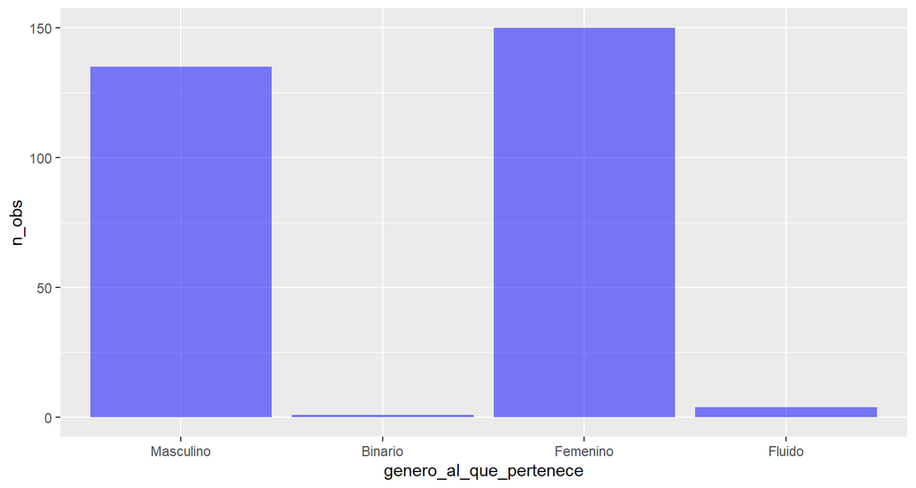

```r
result <- pivotr(
  data,
  cvars = "genero_al_que_pertenece",
  nr = Inf
)
plot(result)
```

```r
# summary()
dtab(result) %>% render()
```

[interactive table not shown]

Podemos notar que en la muestras tomada (de forma sistemática de 1-20) pudimos visualizar un mayor numero de mujeres que fueron más receptivas al momento de realizar la encuesta, además, contamos con algunos otros géneros que no son significativos como el Binario y el Fluido.

Para el caso del tipo de colegio donde estudió o estudia:

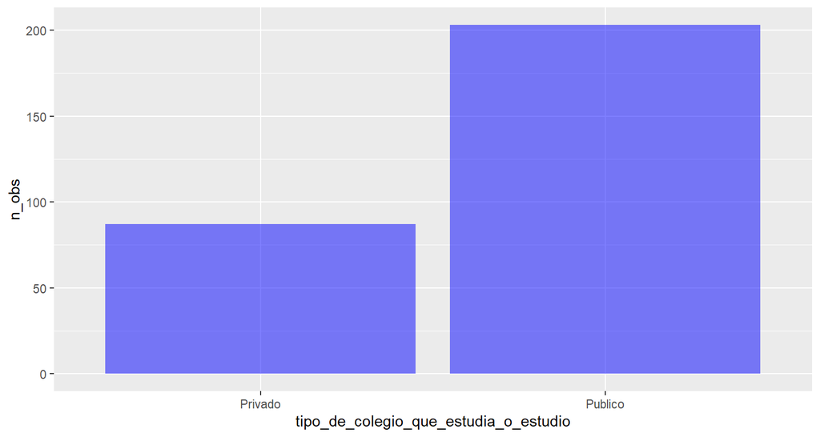

```r
result <- pivotr(
  data,
  cvars = "tipo_de_colegio_que_estudia_o_estudio",
  nr = Inf
)
plot(result, dec = 0)
```

```r
# summary()
dtab(result, dec = 0) %>% render()
```

[interactive table not shown]

Son mayoritarios los colegio que estudian en colegios del estado, revelando que la mayoría de los aspirantes a universidades publicas no vienen de colegios privados.

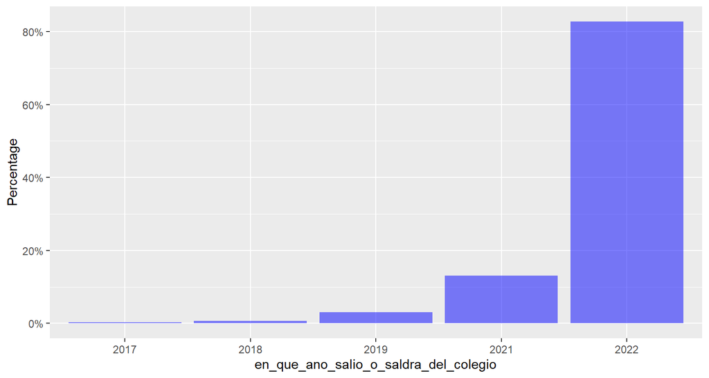

```r
result <- pivotr(
  data,
  cvars = "en_que_ano_salio_o_saldra_del_colegio",
  normalize = "total",
  nr = Inf
)
plot(result, perc = TRUE, dec = 0)
```

```r
# summary()
dtab(result, perc = TRUE, dec = 0) %>% render()
```

[interactive table not shown]

Las promociones de 2022, siempre presentan un numero mayoritario en los aspirantes esto se debe al segundo corte o la prueba de final de año, para el ingreso en el 2023 esto lo decimos ya que podríamos afirmar que en le primer corte los aspirantes salieron del colegio en épocas diferentes, más homogeneidad.

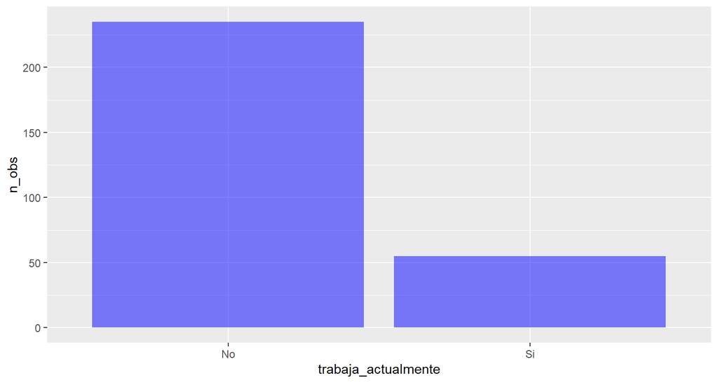

```r
result <- pivotr(
  data,
  cvars = "trabaja_actualmente",
  nr = Inf
)
plot(result, dec = 0)
```

```r
# summary()
dtab(result, dec = 0) %>% render()
```

[interactive table not shown]

En el segundo corte se esperan aspirantes que aun no han salido de estudiar, por ende la mayoría no cuenta con un trabajo, podríamos afirmar que para el primer corte del 2023 estos estudiantes que no ingresaron posiblemente estén laborando para entonces.

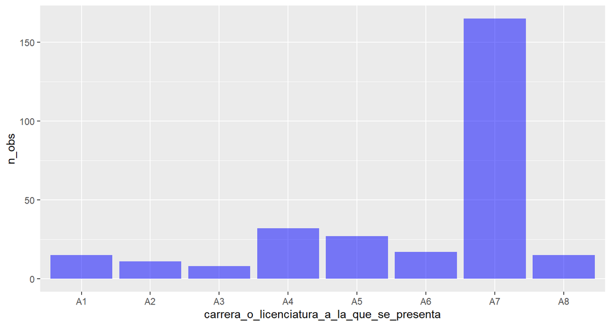

```r
result <- pivotr(
  data,
  cvars = "carrera_o_licenciatura_a_la_que_se_presenta",
  tabsort = "carrera_o_licenciatura_a_la_que_se_presenta",
  nr = Inf
)
plot(result, dec = 0)
```

```r
# summary()
dtab(result, dec = 0) %>% render()
```

[interactive table not shown]

Ahora una de las variables más importantes, es saber cuales son las aspiraciones en áreas de conocimiento de los que hicieron examen de admisión, por lo cual planteamos una vez más las diferentes áreas del saber, en las cuales se aterrorizan todas las carreras brindadas en el estado de Colombia:

- A1 = Agronomía, Veterinaria y afines
- A2 = Bellas Artes
- A3 = Ciencias de la Educación
- A4 = Ciencias de la Salud
- A5 = Ciencias Sociales y Humanas
- A6 = Economía, Administración, Contaduría y afines
- A7 = Ingeniería, Arquitectura, Urbanismo y afines
- A8 = Matemáticas y Ciencias Naturales

Ahora, observando la tabla tenemos que las ingenieras, arquitectura, urbanismo y afines, son el área más demanda de nuestra muestra.

En parte era evidente ya que gran parte de las encuestas fueron realizadas en al UNAL sede Medellín, una universidad que la mayoría, por no decir todas las carreras son de esta área.

```r
result <- pivotr(
  data,
  cvars = "escoja_una_de_las_siguientes_razones_por_la_que_va_a_estudiar",
  tabsort = "desc(n_obs)",
  nr = Inf
)
# summary()
dtab(result, dec = 0, pageLength = 25) %>% render()
```

[interactive table not shown]

Una de las razones por la cual los aspirantes desean entrar a una universidad es porque tienen un alto interés en superarse o bien en estudiar.

```r
result <- pivotr(
  data,
  cvars = "seleccione_la_principal_razon_para_la_eleccion_de_la_carrera_anterior",
  tabsort = "desc(n_obs)",
  nr = Inf
)
# summary()
dtab(result, dec = 0) %>% render()
```

[interactive table not shown]

Ahora esperamos que sea cierto que la mayoría de los aspirantes hayan leído el pensum, para decidir que esta es su linea de interés.

```r
result <- pivotr(
  data,
  cvars = "cuenta_con_algun_estudio_curso_tecnico_entre_otros_certificable_que_este_relacionado_con_la_carrera_que_selecciono",
  nr = Inf
)
# summary()
dtab(result, dec = 0) %>% render()
```

[interactive table not shown]

Aunque creímos que los aspirantes para el 2023 no tendrían una fundamentación en el programa que eligieron, realmente nos dejaron sorprendidos al darnos cuenta que casi 100 personas tienen estudios que se relacionen con su carrera.

```r
result <- pivotr(
  data,
  cvars = "le_interesa_otra_carrera_diferente_a_la_que_se_presento",
  nr = Inf
)
# summary()
dtab(result, dec = 0) %>% render()
```

[interactive table not shown]

```r
result <- pivotr(
  data,
  cvars = "universidad_a_la_que_aspira",
  tabsort = "desc(n_obs)",
  nr = Inf
)
# summary()
dtab(result, dec = 0) %>% render()
```

[interactive table not shown]

Como dijimos anteriormente, la mayoría de nuestros encuestados fueron en la UNAL sede medellín, esto se debe a que hubo un mayor cobertura al ingresar en la universidad, lamentablemente no fue le caso de la UdeA, la gente fue menos receptiva.

```r
result <- pivotr(
  data,
  cvars = c(
    "genero_al_que_pertenece",
    "carrera_o_licenciatura_a_la_que_se_presenta"
  ),
  data_filter = "genero_al_que_pertenece %in% c('Femenino', 'Masculino')",
  tabsort = "desc(Masculino)",
  nr = Inf
)
# summary()
dtab(result, dec = 0) %>% render()
```

[interactive table not shown]

```r
result <- pivotr(
  data,
  cvars = c(
    "trabaja_actualmente",
    "cuenta_con_algun_estudio_curso_tecnico_entre_otros_certificable_que_este_relacionado_con_la_carrera_que_selecciono"
  ),
  data_filter = "genero_al_que_pertenece %in% c('Femenino', 'Masculino')",
  nr = Inf
)
# summary()
dtab(result, dec = 0) %>% render()
```

[interactive table not shown]

```r
result <- pivotr(
  data,
  cvars = c(
    "tipo_de_colegio_que_estudia_o_estudio",
    "escoja_una_de_las_siguientes_razones_por_la_que_va_a_estudiar"
  ),
  tabsort = "desc(Publico)",
  nr = Inf
)
# summary()
dtab(result, dec = 0) %>% render()
```

[interactive table not shown]

Otra comparación que resulta llamativa es comparar el tipo de colegio en el que estudio o estudia y la razón por la cual quiere entrar a una universidad.

Son muy parecidos en el conteo de los estudiantes que quieren superarse y les interesa estudiar que salieron de colegios públicos.